# Project Title

Webscraping Real Estate Websites for Housing Market Analysis

**Project Summary**

In this project we will scrape the **REMAX** website (https://www.remax.ca/) to get information of the housing properties up for sale in different cities across different provinces in Canada. We will be using **Selenium** to assist in scraping the **REMAX** for both the basic and detailed information of each listing across different pages. We will use this scraped data do the following:

- Map these listings to quickly identify regions based on their price
- Plot distributions of housing prices across different regions for comparison
- Visualize housing price distribution based on housing type (condos, single family etc.)
- Find average price of listing across different cities and identify most and least expensive cities
- Identify top 10 most expensive and top 10 least expensive listings
- Analyze *Price* vs *Square Footage* trend for each region and identify any similarities or discrepancies

**List of steps followed:**

- **Step 1**: Gather basic and details data from **REMAX** website for various cities and save them locally
- **Step 2**: Append all the saved scraped data as one pandas dataframe
- **Step 3**: Merge basic and details data on unique #MLS key, perform EDA and treat missing data
- **Step 4**: Correct data types , extract new features and remove redundant or misleading data
- **Step 5**: Use geopy library to extract latitude and longitude coordinates using the address of each listings and add it to dataframe
- **Step 6**: Create a dashboard using **Plotly** and **Dash** to answer all the questions
- **Step 7**: Deploy the dashboard on **heroku** (https://housingmarketanalysis.herokuapp.com/)

# Import Libraries and Custom Functions

## Import Libraries

**Import Core, Geocoding and Plotting Libraries**

```python
# Core Libraries
from time import sleep          # To prevent overwhelming the server between connections
import pandas as pd             # For converting results to a dataframe and bar chart plots
import random                   # For using it to generate random time intervals
import re                       # For regular expressions searches within strings
from selenium import webdriver

# Geocoding Libraries to get Lat Long from address
from geopy.geocoders import Nominatim # For converting address to Lat Long
geolocator = Nominatim(user_agent="remax_app")

# Basic Visualization Libraries
import matplotlib.pyplot as plt
import seaborn as sns

# Import Plotly and Dash Libraries for Dashboard
import plotly.express as px
import plotly.graph_objects as go
import dash
import dash_core_components as dcc
import dash_html_components as html
import plotly.figure_factory as ff

# Auto reloading configuration
%load_ext autoreload
%autoreload 2
%matplotlib inline
```

## Import *custom_functions* and *app_layouts* Function

**custom_functions** and **app_layouts** functions are save in functions folder in the project directory.

- **custom_functions** contains following functions:
  - **web_scrape:** This function scrapes the listing information of real estate properties from REMAX website and store the into two seperate lists basic_info and detail_info lists
  - **listtodataframe:** Function to convert scraped list of basic_info and detail_info in to respective dataframes
  - **missing_data_stats:** Reads a dataframe and generates its statistics and missing value tables
  - **sqft_area:** Takes square footage column as an input and extracts numbers from it where a range is reported like 600-700 sqft an average of these numbers is taken
  - **area_from_dims:** Function to generate area from room dimension tables
  - **latlong:** Function to convert address to lat long coordinates
- **app_layout** contains following function:
  - **pe_8_grid_3cols_layout:** Function to generates a 8 grid layout of dash web app spread across three columns. The 1st column has two rows, the 2nd and 3rd each have 3 rows.

```python
# Import custom functions
from functions import custom_functions as cf

# Import app layout functions
from functions.app_layouts import *
```

# Run Webscraping Functions

## Run *web_scrape* function and save list then run *listtodataframe* function to create and save pandas DataFrames from these lists

run **help(cf.web_scrape)** and **help(cf.listtodataframe)** to get more information on these function

**NOTE: Uncomment the code below if you want to scrape more data and make sure to update chrome_driver_path to path on your machine**

```python
# #----------------------------------------------------------------------------------------
# # INPUTS
# #----------------------------------------------------------------------------------------
# # Make sure to update chrome_driver_path to path on your machine
# chrome_driver_path = '/Users/wk/Documents/01-Courses/9-WeCloudBootcamp/Bootcamp/2-Python/Week 2/chromedriver'
# province = 'on'
# city = 'hamilton'
# num_pages = 23

# basic_info, detail_info = cf.web_scrape(province, city, num_pages, chrome_driver_path)

# #----------------------------------------------------------------------------------------
# # Save scraped lists to files
# #----------------------------------------------------------------------------------------
# with open(city+'_'+province+'_'+'basic_info.txt', 'w') as f:
#     for item in basic_info:
#         f.write("%s\n" % item)

# with open(city+'_'+province+'_'+'details_info.txt', 'w') as f:
#     for item in detail_info:
#         f.write("%s\n" % item)

# #----------------------------------------------------------------------------------------
# # Create and save dataframes
# #----------------------------------------------------------------------------------------
# ba_df, de_df = cf.listtodataframe(basic_info, detail_info)

# ba_df.to_csv(city+'_'+province+'_'+'basic_df')
# de_df.to_csv(city+'_'+province+'_'+'detail_df')
```

# Combine Allthe Saved Webscraping Data From Different Runs Together as a Single DataFrame

```python
#----------------------------------------------------
# Read all the saved webscraped data
#----------------------------------------------------

# Toronto
tor_basic_df  = pd.read_csv('Toronto/toronto_on_basic_df', index_col=0)
tor_basic_df['Region'] = 'Toronto'
tor_detail_df = pd.read_csv('Toronto/toronto_on_detail_df', index_col=0)

# Vancouver
van_basic_df  = pd.read_csv('Vancouver/vancouver_bc_basic_df', index_col=0)
van_basic_df['Region'] = 'Vancouver'
van_detail_df = pd.read_csv('Vancouver/vancouver_bc_detail_df', index_col=0)

# Ottawa
ott_basic_df  = pd.read_csv('Ottawa/ottawa_on_basic_df', index_col=0)
ott_basic_df['Region'] = 'Ottawa'
ott_detail_df = pd.read_csv('Ottawa/ottawa_on_detail_df', index_col=0)

# Hamilton
ham_basic_df  = pd.read_csv('Hamilton/hamilton_on_basic_df', index_col=0)
ham_basic_df['Region'] = 'Hamilton'
ham_detail_df = pd.read_csv('Hamilton/hamilton_on_detail_df', index_col=0)

# Calgary
cal_basic_df  = pd.read_csv('Calgary/calgary_ab_basic_df', index_col=0)
cal_basic_df['Region'] = 'Calgary'
cal_detail_df = pd.read_csv('Calgary/calgary_ab_detail_df', index_col=0)

# Halifax
hal_basic_df  = pd.read_csv('Halifax/halifax_ns_basic_df', index_col=0)
hal_basic_df['Region'] = 'Halifax'
hal_detail_df = pd.read_csv('Halifax/halifax_ns_detail_df', index_col=0)

#----------------------------------------------------------------
# Merge basic and details information from all scraped sources
#----------------------------------------------------------------
basic_df_sources = [tor_basic_df, van_basic_df, ott_basic_df ,
                    cal_basic_df, ham_basic_df, hal_basic_df]

details_df_sources = [tor_detail_df, van_detail_df, ott_detail_df ,
                      cal_detail_df, ham_detail_df, hal_detail_df]

# Merge basic dataframes
basic_df = pd.DataFrame()
for df in basic_df_sources:
    basic_df = basic_df.append(df)

# Merge details dataframes
details_df = pd.DataFrame()
for df in details_df_sources:
    details_df = details_df.append(df)
```

# EDA and Data Preprocessing

## Show first few rows

```python
print('Basic Information DataFrame')
display(basic_df.head(3))

print('\n')

print('Detailed Information DataFrame')
details_df.head(3)
```

```
Basic Information DataFrame
```

|  | Price | Beds | Baths | Address | MLS# | Tag1 | Tag2 | Region |
| --- | --- | --- | --- | --- | --- | --- | --- | --- |
| 0 | $2,998,000 | n/a bed | n/a bath | 216 Keele St, Toronto, ON | W5499582 | NEW | NaN | Toronto |
| 1 | $669,000 | 2 bed | 2 bath | 3119 - 9 Mabelle Ave, Toronto, ON | W5499548 | NEW | NaN | Toronto |
| 2 | $589,900 | 1 bed | 1 bath | 1506 - 458 Richmond St W, Toronto, ON | C5499565 | NEW | NaN | Toronto |

```
Detailed Information DataFrame
```

|  | Property Tax | Last Updated | MLS® # | Date Listed | Property Type | Square Footage | Cooling | Water | Business Type | Board | ... | District | Road | PID YN | Land Features | Sub-Area | Sale Or Rent | Documents On File | Virt Tour Pub Site Access | Income Property | Conditional Clause |
| --- | --- | --- | --- | --- | --- | --- | --- | --- | --- | --- | --- | --- | --- | --- | --- | --- | --- | --- | --- | --- | --- |
| 0 | N/A | Sat, February 12, 2022 | W5499582 | Feb 12, 2022 | MultiFamily | 4051.96 sqft SQFT | Partially air conditioned | Municipal water |  | Toronto Real Estate Board | ... | NaN | NaN | NaN | NaN | NaN | NaN | NaN | NaN | NaN | NaN |
| 1 | N/A | Sat, February 12, 2022 | W5499548 | Feb 12, 2022 | Condo | NaN | Central air conditioning | NaN | NaN | Toronto Real Estate Board | ... | NaN | NaN | NaN | NaN | NaN | NaN | NaN | NaN | NaN | NaN |
| 2 | N/A | Sat, February 12, 2022 | C5499576 | Feb 12, 2022 | Rental | NaN | Central air conditioning | NaN | NaN | Durham Region Association of REALTORS | ... | NaN | NaN | NaN | NaN | NaN | NaN | NaN | NaN | NaN | NaN |

3 rows × 284 columns

## Merge tables into one using MLS# as common key

- Do a left join with **basic_df** as base table to keep all the basic listing information
- Save as **remax** dataframe
- Display first few rows of this **merged remax** table

```python
remax = pd.merge(basic_df, details_df, how = 'left', left_on='MLS#', right_on='MLS® #')
remax.head(3)
```

|  | Price | Beds | Baths | Address | MLS# | Tag1 | Tag2 | Region | Property Tax | Last Updated | ... | District | Road | PID YN | Land Features | Sub-Area | Sale Or Rent | Documents On File | Virt Tour Pub Site Access | Income Property | Conditional Clause |
| --- | --- | --- | --- | --- | --- | --- | --- | --- | --- | --- | --- | --- | --- | --- | --- | --- | --- | --- | --- | --- | --- |
| 0 | $2,998,000 | n/a bed | n/a bath | 216 Keele St, Toronto, ON | W5499582 | NEW | NaN | Toronto | N/A | Sat, February 12, 2022 | ... | NaN | NaN | NaN | NaN | NaN | NaN | NaN | NaN | NaN | NaN |
| 1 | $669,000 | 2 bed | 2 bath | 3119 - 9 Mabelle Ave, Toronto, ON | W5499548 | NEW | NaN | Toronto | N/A | Sat, February 12, 2022 | ... | NaN | NaN | NaN | NaN | NaN | NaN | NaN | NaN | NaN | NaN |
| 2 | $589,900 | 1 bed | 1 bath | 1506 - 458 Richmond St W, Toronto, ON | C5499565 | NEW | NaN | Toronto | NaN | NaN | ... | NaN | NaN | NaN | NaN | NaN | NaN | NaN | NaN | NaN | NaN |

3 rows × 292 columns

## Get dataframe stats

### Run *missing_data_stats* Function

run **help(cf.missing_data_stats)** to get more information on this function

- Plot a heatmap of missing values to visualize all missing values
- Bin the missing data percentage and count how many columns fall in each category

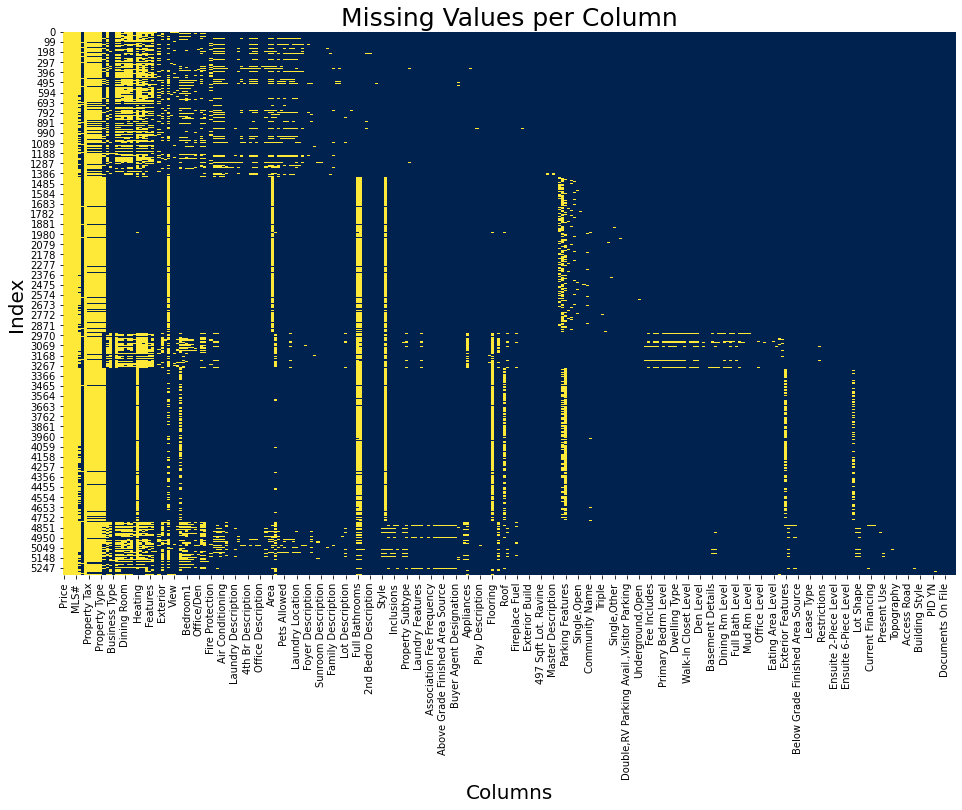

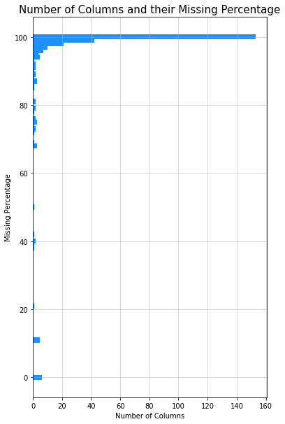

```python
#----------------------------------------------------------------
# Run missing_data_stats function
#----------------------------------------------------------------
data_stats, missing_by_cols, missing_by_bins , missing_by_row =  cf.missing_data_stats(remax)

#----------------------------------------------------------------
# Missing values plot per Column
#----------------------------------------------------------------
plt.figure(figsize = (16,10))
sns.heatmap(remax.notnull(), cbar=False, cmap='cividis')
plt.title('Missing Values per Column', size=25)
plt.xlabel('Columns', size=20)
plt.ylabel('Index', size=20)
plt.savefig('Missing Values per Column.jpeg', dpi=600)
plt.show()

#----------------------------------------------------------------
# Count of Columns with Similars Missing Values (binned)
#----------------------------------------------------------------
plt.figure(figsize = (6,10))
plt.barh(missing_by_bins.index ,missing_by_bins['Missing_Values'],height=1.5,color='dodgerblue')
plt.title('Number of Columns and their Missing Percentage', size=15)
plt.xlabel('Number of Columns', size=10)
plt.ylabel('Missing Percentage', size=10)
plt.grid(alpha=0.6)
plt.savefig('Number of Columns and their Missing Percentage.jpeg', dpi=600)
plt.show()
```

## Data Preprocessing

### Remove columns which have more than threshold percentage of data missing

```python
# Set the percentage threshold
threshold = 90

# Identify list of columns with missing percentage values above the set threshold
cols_below_threshold = (missing_by_cols[missing_by_cols
                          ['Missing_Percentage_Rounded'] > threshold].index)

# Drop the columns from the dataframe
remax.drop(cols_below_threshold, axis=1, inplace =True)
```

### Correct Data Types , Extract Features and Clean Data

```python
#------------------------------------------------------------------------------
# Trim all columns and Replace NaNs for room dimension columns
#------------------------------------------------------------------------------
remax = remax.apply(lambda x: x.str.strip() if x.dtype == "object" else x)

# Replac NaNs with empty strings
remax['Bedroom'].fillna('', inplace =True)
remax['Dining Room'].fillna('', inplace =True)
remax['Living Room'].fillna('', inplace =True)
remax['Kitchen'].fillna('', inplace =True)

#------------------------------------------------------------------------------
# Add Extra Feature Columns
#------------------------------------------------------------------------------
# Add Province Name Column
remax['Province'] = remax['Address'].apply(lambda x:x.split(',')[-1].strip())

# Add City Name Column
remax['City'] = remax['Address'].apply(lambda x:x.split(',')[-2].strip())

# Add Street Name Column From Address
remax['Street'] = remax['Address'].apply(lambda x:x.split(',')[-3])
remax['Street'] = (remax['Street'].apply(lambda x:
                        (re.findall('(-?\d*.*\w*)',x)[0]).split('-')[-1].strip()))

# Create a Street_City column to later use for lat, long coordinates
remax['Street_City'] = remax['Street'] + ' , ' +remax['City']

# Extract Property Tax Amount from Property Tax attribute
remax['Property Tax'] = remax['Property Tax'].replace('N/A',np.NaN)
remax['Property Tax Amount'] =  (remax['Property Tax'].apply(lambda x:str(x).split('(')[0].
                                                        replace('$','').replace(',','').
                                                            strip()))

remax['Property Tax Amount'] = remax['Property Tax Amount'].astype(float)

# Add area features using custom functions
remax['Total_Sqft'] = cf.sqft_area(remax, 'Square Footage')
remax['Bedroom_Sqm'] = cf.area_from_dims(remax,'Bedroom')
remax['Dining_Sqm'] = cf.area_from_dims(remax,'Dining Room')
remax['Living_Sqm'] = cf.area_from_dims(remax,'Living Room')
remax['Kitchen_Sqm'] = cf.area_from_dims(remax,'Kitchen')

#------------------------------------------------------------------------------
# Convert data types and Drop redundant columns and Rows
#------------------------------------------------------------------------------
# Convert Price to Integer
remax['Price'] = remax['Price'].apply(lambda x:int(x.replace('$','').replace(',','')))

# Convert date objects to datetime
remax['Date Listed'] = pd.to_datetime(remax['Date Listed'])
remax['Last Updated'] = pd.to_datetime(remax['Last Updated'])

#------------------------------------------------------------------------------
# Column Operations
#------------------------------------------------------------------------------
# Keep only these relevant columns
filter_list = (['MLS#','Province','Region','City', 'Subdivision','Street','Address',
                'Street_City', 'Property Type','Date Listed', 'Price',
                'Beds', 'Baths', 'Total_Sqft', 'Bedroom_Sqm', 'Dining_Sqm',
                'Living_Sqm', 'Kitchen_Sqm',

                'Cooling', 'Heating','Parking', 'Basement',
                'Amenities', 'Features', 'Exterior Features'])

remax = remax[filter_list]

#------------------------------------------------------------------------------
# Row Operations
#------------------------------------------------------------------------------
# Drop Rows where Property Type is unkown or is a Vacant Land
remax = remax[remax['Property Type'].notnull()]
remax = remax[remax['Property Type']!='Vacant Land']

# Drop Rows where Beds are unknown
remax = remax[remax['Beds']!='n/a bed']

# Drop Anomalous Total_Sqft and Misleading House Values
remax.drop(remax.loc[remax['Total_Sqft']>30000].index, inplace=True)
remax.drop(remax.loc[remax['Price']<100000].index, inplace=True)
```

### Run *latlong* Function and Fetch Longitude and Latitude Information using Street and City Address and Save Final Cleaned DataFrame

run **help(cf.latlong)** to get more information on this function

**NOTE: The following block of code takes a while to execute since it runs geopy functions on each and every address one at a time**

```python
#------------------------------------------------------------------------------
# Extract Lat Long using latlong function
#------------------------------------------------------------------------------
# Create LatLong column
remax['LatLong'] = remax['Street_City'].apply(lambda x:cf.latlong(x))

# Extract Langitude and Longitude From LatLong column
remax['Latitude'] = remax['LatLong'].apply(lambda x:x[0])
remax['Longitude'] = remax['LatLong'].apply(lambda x:x[1])

# Save the final cleaned DataFrame
remax.to_csv('remax_df.csv', index=False)
```

# Create a Dash App Using Plotly

**Run *pe_8_grid_3cols_layout* Function to Initialize and create the Dash App </font>**

run **help(pe_8_grid_3cols_layout)** to get more information on this function

```python
#---------------------------------------------------------------------------------
# Specify the filter controls properties and run app initialization
#---------------------------------------------------------------------------------
module_title = 'RealEstate Price Analysis'
dropdown_filter_property = 'Province'
dropdown_filter_property2 = 'Beds'
range_filter_property = 'Price'
checkbox_filter_property = 'Property Type'

# Create a dataframe
df = pd.read_csv('remax_df.csv')

# Filter to Longitudes and Latitudes within Canada, remove wrong coordinates
df = df[(df['Longitude']<-40) & (df['Latitude']>40)]

app = pe_8_grid_3cols_layout(module_title, df,
                             dropdown_filter_property,dropdown_filter_property2,
                             range_filter_property, checkbox_filter_property)


#---------------------------------------------------------------------------------
# Run the app and add visualizations
#---------------------------------------------------------------------------------
# Specify the input for callbacks and outputs to be retured
####################################################################################
@app.callback(
    [Output('fig1','figure'),
     Output('fig2','figure'),
     Output('fig3','figure'),
     Output('fig4','figure'),
     Output('fig5','figure'),
     Output('fig6','figure'),
     Output('fig7','figure'),],
    [Input('dropdown_id','value'),
     Input('dropdown_id2','value'),
     Input('range_id','value'),
     Input('checkbox_id','value')])

# Set up plots
#---------------------------------------------------------------------------------
# Function which runs and updates plots based on change of filters
#---------------------------------------------------------------------------------
def update_graph(dropdown_id, dropdown_id2, range_id, checkbox_id):
    dff = df[df[dropdown_filter_property].isin(list(dropdown_id))]
    dff = dff[dff[dropdown_filter_property2].isin(list(dropdown_id2))]
    dff = dff[(dff[range_filter_property] >= min(range_id)) & (dff[range_filter_property] <= max(range_id))]
    dff = dff[dff[checkbox_filter_property].isin(list(checkbox_id))]

    #---------------------------------------------------------------------------------
    # Create all the required plots to populate on callback
    #---------------------------------------------------------------------------------
    px.set_mapbox_access_token('pk.eyJ1Ijoid2NkLXBhcnJ5IiwiYSI6ImNrZ2F3emExaTA1MTMyem1xYWlxaTJmOXQifQ.uNDZBfkfSYD1JxGsW94fzg')
    fig1 = px.scatter_mapbox(dff, 'Latitude', 'Longitude',color='Region',size='Price',
                             template='custom',hover_name = 'Address',zoom=3)

    fig2 = px.violin(dff,'Region','Price',color='Region',template='custom', points = False,
                   title='Price by Region')
    fig2.update_layout(showlegend=False)
    fig2.update_yaxes(range=[0, 3e6])

    fig3 = px.box(dff, 'Price', 'Property Type', color='Property Type',template='custom',
                  title = 'Price Distribution by Unit Type')
    fig3.update_layout(showlegend=False)
    fig3.update_xaxes(range=[0, 7e6])


    mean_price_city = dff.groupby(dff['City'].str.capitalize()).mean()[['Price']].sort_values(by='Price',
                                                                                             ascending=False)
    fig4 = px.bar(mean_price_city, 'Price', mean_price_city.index ,
                  color=mean_price_city.index,template='custom',
                  title = 'Average Price by City')
    fig4.update_layout(showlegend=False)

    expensive_vs_cheap = dff.groupby(dff['Address']).mean()[['Price']].sort_values(by='Price')
    expensive = expensive_vs_cheap.tail(10)
    fig5 = px.bar(expensive, 'Price', expensive.index, color = 'Price', template='custom',
                  color_continuous_scale=px.colors.sequential.Viridis_r,
                  title = 'Ten Most Expensive Listings')

    cheap = expensive_vs_cheap.head(10)
    fig6 = px.bar(cheap, 'Price', cheap.index, color='Price', template='custom',
                  color_continuous_scale=px.colors.sequential.Viridis_r,
                  title = 'Ten Least Expensive Listings')
    fig6.update_yaxes(autorange='reversed')

    fig7 = px.scatter(dff, 'Total_Sqft' , 'Price',color='Region', trendline='ols',
                      template='custom',
                      title = 'Price vs Area Correlation')
    fig7.update_yaxes(range=[0, 20e6])

    return fig1,fig2, fig3, fig4, fig5, fig6, fig7


if __name__ == '__main__':
    app.run_server(debug=True, use_reloader=False)
```

```
Dash is running on http://127.0.0.1:8050/

 * Serving Flask app "__main__" (lazy loading)
 * Environment: production
   WARNING: This is a development server. Do not use it in a production deployment.
   Use a production WSGI server instead.
 * Debug mode: on
```

# Deploy Dash App on Heoku

**App deployed at the following link**

https://housingmarketanalysis.herokuapp.com/

[figure not shown]